# Blood Pressure Study - Project 1

Oliver Yawlui

2024-09-22

# FULL ANALYSIS

### Introduction

This study compares the effectiveness of three drugs; Ramipril, Lisinopril, and Moexipril in reducing systolic blood pressure (BP). Each drug was administered to four randomly assigned subjects, and systolic BP was measured before and after treatment. The primary objectives of the study are:

1. To determine whether the three drugs are equally effective in reducing mean blood pressure.
2. If differences exist, which is the best drug?
3. Perform a statistical investigation of whether the data support or refute the claim that the individuals were assigned randomly to the drugs.

### Methods

**Data Description:**

The dataset includes three variables: systolic BP before and after treatment, and the drug administered. Each drug group consists of four subjects, totaling 12 subjects in the study.

**Data Processing:**

Calculated endpoints include:

1. BP Change: Difference between post- and pre-treatment BP.
2. Relative BP Change: The ratio of BP change relative to pre-treatment BP.
3. Percentage Drop Relative to 120 mmHg: A measure expressing the percentage drop from pre-treatment BP, standardized to a target of 120 mmHg.

**Statistical Models and Tests:**

1. Three ANOVA models were used to compare changes in BP, relative changes, and percentage drops among the drug groups. ANCOVA models were conducted to adjust for initial BP levels, examining whether accounting for pre-treatment BP affected the drug comparisons.
2. Assessment of Randomization: To verify the claim of randomization, pre-treatment BP values were compared among the drug groups using:
- One-Way ANOVA : A parametric approach to test for equality of mean pre-treatment BP.
- Kruskal-Wallis Test : A nonparametric alternative to ANOVA that tests for differences in median values.

### Results

**1. Mean and Standard Deviations by Drug:**

The study of data for the three drugs; Lisinopril, Moexipril, and Ramipril shows significant changes in systolic blood pressure (BP) before and after treatment. All three medicines result in a considerable drop in mean systolic blood pressure after treatment. Moexipril shows the greatest mean decrease (-44.5 mmHg), followed by Lisinopril (-38.75 mmHg) and Ramipril (-32.0 mmHg). Moexipril has the biggest relative BP change (-0.2558), whilst Ramipril has the smallest (-0.1772).

Moexipril has the biggest percentage drop in blood pressure (85.36%), followed by Lisinopril (77.04%) and Ramipril (54.31%). The standard deviations (SD) show that Moexipril has the least variability in post-BP readings (SD = 4.92), indicating more consistent effects, whereas Lisinopril has the most variability in BP change.

**2. One way ANOVA results**

- Model 1 (ANOVA on BP change among drugs) reveals that there is no statistically significant difference in BP change among the drugs (F = 1.374, p = 0.302). The p-value is much higher than 0.05, indicating that the mean BP change is not significantly different across the drug groups.
- Model 2 (ANOVA on relative BP change) also shows no statistically significant difference in the relative BP changes across the drugs (F = 2.72, p = 0.119). Though the F-value is higher compared to Model 1, the p-value is still above the 0.05 threshold, suggesting that relative change in BP is consistent across the drugs.
- Model 3 (ANOVA on percentage drop relative to 120 mmHg) indicates a significant difference among the drugs (F = 7.381, p = 0.0127). The p-value is less than 0.05, suggesting that the percentage drop in systolic BP relative to 120 mmHg varies significantly between the drugs.

**4. Assessment of Randomization:**

- One-way ANOVA: This test was conducted to check if the randomization was effective, meaning that pre-treatment BP should not significantly differ between the groups. The hypotheses are; H_0: There is no difference in the mean pre-study BP across the different drug groups vrs H_a: There is a difference in the mean pre-study BP across at least one of the drug groups. Since the p-value is 0.584 (greater than 0.05), we fail to reject the null hypothesis, indicating that there is no significant difference in the pre-study BP across the drug groups. This suggests that the randomization process was effective, as the groups started with similar baseline BP levels.
- Kruskal-Wallis Test: This test is useful when we cannot assume the normality of the data, as in the parametric approach. The Kruskal-Wallis chi-squared value is 0.80769, with a p-value of 0.6677. Since the p-value is much larger than 0.05, we fail to reject the null hypothesis. The non-parametric Kruskal-Wallis test indicates that there is no significant difference in the distribution of pre-study BP across the drug groups. This supports the idea that the randomization was effective, and the groups started with similar baseline BP distributions.

### Conclusion

**Effectiveness of the drug:**

Both the parametric one-way ANOVA and the non-parametric Kruskal-Wallis test on pre-study BP distributions confirmed that there is no significant difference in the pre-study systolic BP across the drug groups. This validates that the randomization process was successful, as the groups were balanced in terms of their initial BP levels.

## APPENDIX

```r
library(tidyverse)
library(gridExtra)
library(knitr)
```

### Data processing and calculation of different endpoints

```r
bpdata <- bpdata %>%
  mutate(subject = factor(subject),
         BPchange = after-before,                                # straight pre/post diff
         rel.BPchange = (after-before)/before,                   # change relative to initial
         BP.pct.drop.120 = 100*(before-after)/(before-120)) %>%  # % drop rel to 120 (interp?)
  rename(ID = subject,
         Drug = drug,
         SysBP.pre = before,
         SysBP.post = after)
bpdata
```

```
##    ID       Drug SysBP.pre SysBP.post BPchange rel.BPchange BP.pct.drop.120
## 1   1   Ramipril       194        157      -37   -0.1907216        50.00000
## 2   2   Ramipril       162        136      -26   -0.1604938        61.90476
## 3   3   Ramipril       183        145      -38   -0.2076503        60.31746
## 4   4   Ramipril       180        153      -27   -0.1500000        45.00000
## 5   5 Lisinopril       154        124      -30   -0.1948052        88.23529
## 6   6 Lisinopril       184        123      -61   -0.3315217        95.31250
## 7   7 Lisinopril       173        143      -30   -0.1734104        56.60377
## 8   8 Lisinopril       170        136      -34   -0.2000000        68.00000
## 9   9  Moexipril       158        124      -34   -0.2151899        89.47368
## 10 10  Moexipril       165        124      -41   -0.2484848        91.11111
## 11 11  Moexipril       186        132      -54   -0.2903226        81.81818
## 12 12  Moexipril       182        133      -49   -0.2692308        79.03226
```

### Mean responses by drug

| Drug | mean_SysBP.pre | mean_SysBP.post | mean_BPchange | mean_rel.BPchange | mean_BP.pct.drop.120 |
| --- | --- | --- | --- | --- | --- |
| Lisinopril | 170.25 | 131.50 | -38.75 | -0.2249343 | 77.03789 |
| Moexipril | 172.75 | 128.25 | -44.50 | -0.2558070 | 85.35881 |
| Ramipril | 179.75 | 147.75 | -32.00 | -0.1772164 | 54.30556 |

### SDs of responses by drug

| Drug | sd_SysBP.pre | sd_SysBP.post | sd_BPchange | sd_rel.BPchange | sd_BP.pct.drop.120 |
| --- | --- | --- | --- | --- | --- |
| Lisinopril | 12.39287 | 9.678154 | 14.952703 | 0.0719840 | 17.875307 |
| Moexipril | 13.40087 | 4.924429 | 8.812869 | 0.0320150 | 5.847577 |
| Ramipril | 13.27592 | 9.287088 | 6.377042 | 0.0266395 | 8.144980 |

```r
# Load necessary libraries
library(dplyr)
library(knitr)
library(car)
library(emmeans)
# Read in data
bpdata <- read.csv("/Users/presidentoliver/Desktop/Practicum in Data Analysis/Project 1 - Blood pressure study/bloodpressurestudy.csv")
#names(bpdata)

bpdata <- bpdata %>%
  mutate(subject = factor(subject),
         BPchange = after-before,                                # straight pre/post diff
         rel.BPchange = (after-before)/before,                   # change relative to initial
         BP.pct.drop.120 = 100*(before-after)/(before-120)) %>%  # % drop rel to 120 (interp?)
  rename(ID = subject,
         Drug = drug,
         SysBP.pre = before,
         SysBP.post = after)



# calculate both mean and standard deviation for BP_Change by Drug
formatted_table <- bpdata %>%
  group_by(Drug) %>%
  summarize(
    mean_BP_Change = mean(BPchange, na.rm = TRUE),
    sd_BP_Change = sd(BPchange, na.rm = TRUE)
  ) %>%
  kable(format = "html", digits = 2, caption = "Table 1")  # Adding a caption

# Print formatted table
formatted_table
```

Table 1

| Drug | mean_BP_Change | sd_BP_Change |
| --- | --- | --- |
| Lisinopril | -38.75 | 14.95 |
| Moexipril | -44.50 | 8.81 |
| Ramipril | -32.00 | 6.38 |

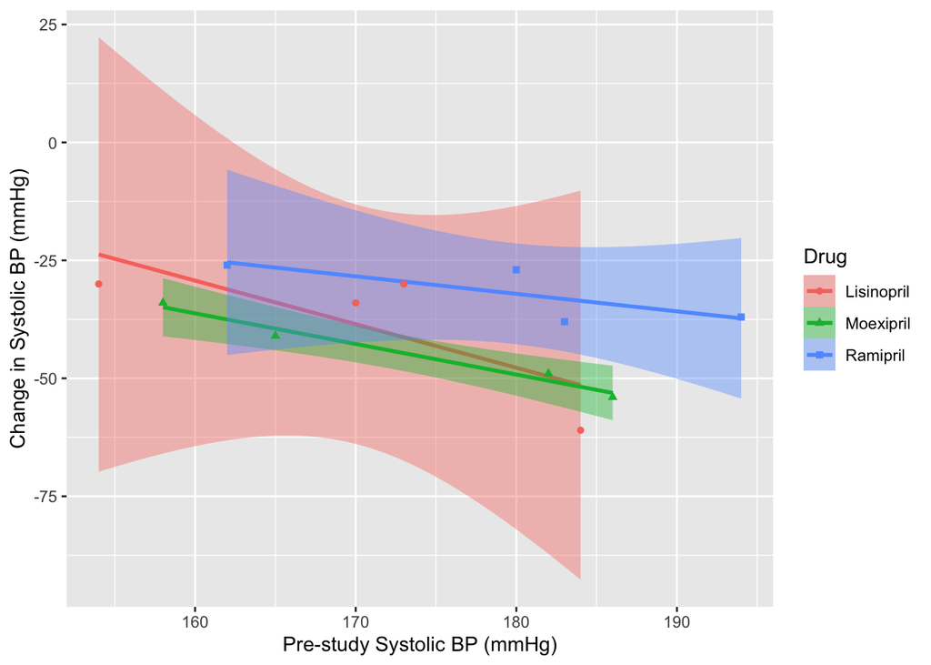

```r
### Model 5: One-way ANCOVA on change in BP, using pre-study BP as a covariate

# Visualization
ggplot(bpdata, aes(x=SysBP.pre, y=BPchange, shape=Drug, colour=Drug, fill=Drug)) +
  geom_smooth(method="lm") +
  geom_point() +
  labs(x = "Pre-study Systolic BP (mmHg)",
       y = "Change in Systolic BP (mmHg)")
```

```r
# Modeling
ancova2 <- aov(BPchange ~ SysBP.pre + Drug, data = bpdata)



# Multiple comparison - simultaneous CIs
emmeans(ancova2, specs = pairwise ~ Drug)
```

```
## $emmeans
##  Drug       emmean   SE df lower.CL upper.CL
##  Lisinopril  -41.3 3.65  8    -49.7    -32.9
##  Moexipril   -45.5 3.59  8    -53.7    -37.2
##  Ramipril    -28.5 3.71  8    -37.1    -19.9
##
## Confidence level used: 0.95
##
## $contrasts
##  contrast               estimate   SE df t.ratio p.value
##  Lisinopril - Moexipril     4.16 5.08  8   0.820  0.7021
##  Lisinopril - Ramipril    -12.78 5.35  8  -2.391  0.0992
##  Moexipril - Ramipril     -16.95 5.22  8  -3.249  0.0282
##
## P value adjustment: tukey method for comparing a family of 3 estimates
```

```r
# Get the emmeans output
emmeans_output <- emmeans(ancova2, specs = pairwise ~ Drug)

# Format the contrast results using kable
contrast_table <- as.data.frame(emmeans_output$contrasts)

# Use kable to format the table for Word
kable(contrast_table, format = "markdown", caption = "Pairwise Comparisons of Drugs") %>%
  print()
```

```
##
##
## Table: Pairwise Comparisons of Drugs
##
## |contrast               |   estimate|       SE| df|    t.ratio|   p.value|
## |:----------------------|----------:|--------:|--:|----------:|---------:|
## |Lisinopril - Moexipril |   4.161991| 5.077354|  8|  0.8197165| 0.7020515|
## |Lisinopril - Ramipril  | -12.784435| 5.347005|  8| -2.3909522| 0.0992435|
## |Moexipril - Ramipril   | -16.946426| 5.216330|  8| -3.2487260| 0.0282393|
```

```r
# Nonparametric test to compare distributions of pre-study BP
kruskal_result <- kruskal.test(SysBP.pre ~ Drug, data = bpdata)


# Extract the necessary values
kruskal_df <- data.frame(
  Statistic = kruskal_result$statistic,
  Degrees_of_Freedom = kruskal_result$parameter,
  P_value = kruskal_result$p.value
)
kable(kruskal_df, format = "html", digits = 3, caption = "Kruskal-Wallis Test for Pre-treatment BP") %>%
  print()
```

[output not shown]

### Visualizations

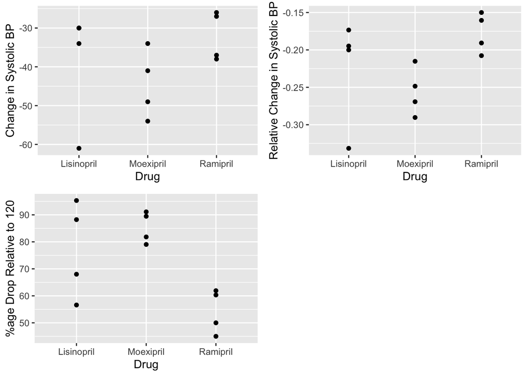

```r
p1 <- ggplot(bpdata) + geom_point(aes(x=Drug, y=BPchange)) +
  labs(y="Change in Systolic BP")
p2 <- ggplot(bpdata) + geom_point(aes(x=Drug, y=rel.BPchange)) +
  labs(y="Relative Change in Systolic BP")
p3 <- ggplot(bpdata) + geom_point(aes(x=Drug, y=BP.pct.drop.120)) +
  labs(y="%age Drop Relative to 120")

grid.arrange(p1, p2, p3, ncol = 2, nrow = 2)
```

### Some Different Modeling Strategies

#### Model 1: One-way ANOVA on BP change

```r
# One-way ANOVA to compare BP change among drugs
anova1 <- aov(BPchange ~ Drug, data = bpdata)
summary(anova1)
```

```
##             Df Sum Sq Mean Sq F value Pr(>F)
## Drug         2  313.2   156.6   1.374  0.302
## Residuals    9 1025.8   114.0
```

#### Model 2: One-way ANOVA on BP change relative to pre-study BP

```r
# One-way ANOVA on relative change in BP
anova2 <- aov(rel.BPchange ~ Drug, data = bpdata)
summary(anova2)
```

```
##             Df  Sum Sq  Mean Sq F value Pr(>F)
## Drug         2 0.01254 0.006271    2.72  0.119
## Residuals    9 0.02075 0.002305
```

#### Model 3: One-way ANOVA on %age Drop Relative to 120

```r
# One-way ANOVA on % drop relative to 120 mmHg
anova3 <- aov(BP.pct.drop.120 ~ Drug, data = bpdata)
summary(anova3)
```

```
##             Df Sum Sq Mean Sq F value Pr(>F)
## Drug         2   2067    1034   7.381 0.0127 *
## Residuals    9   1260     140
## ---
## Signif. codes:  0 '***' 0.001 '**' 0.01 '*' 0.05 '.' 0.1 ' ' 1
```

#### Model 4: One-way ANCOVA on post-study BP, using pre-study BP as a covariate

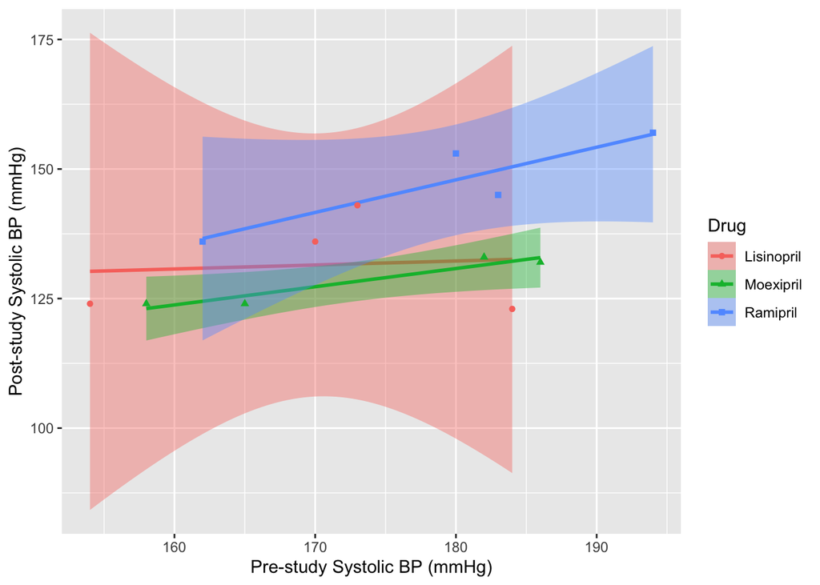

```r
# Visualization
ggplot(bpdata, aes(x=SysBP.pre, y=SysBP.post, shape=Drug, colour=Drug, fill=Drug)) +
  geom_smooth(method="lm") +
  geom_point() +
  labs(x = "Pre-study Systolic BP (mmHg)",
       y = "Post-study Systolic BP (mmHg)")
```

```r
# Modeling

ancova1 <- aov(SysBP.post ~ SysBP.pre + Drug, data = bpdata)
summary(ancova1)
```

```
##             Df Sum Sq Mean Sq F value Pr(>F)
## SysBP.pre    1  507.1   507.1   9.915 0.0136 *
## Drug         2  569.5   284.7   5.568 0.0305 *
## Residuals    8  409.1    51.1
## ---
## Signif. codes:  0 '***' 0.001 '**' 0.01 '*' 0.05 '.' 0.1 ' ' 1
```

```r
# Perform Tukey test in R
TukeyHSD(ancova1, "Drug")
```

```
##   Tukey multiple comparisons of means
##     95% family-wise confidence level
##
## Fit: aov(formula = SysBP.post ~ SysBP.pre + Drug, data = bpdata)
##
## $Drug
##                          diff        lwr       upr     p adj
## Moexipril-Lisinopril -4.60651 -19.055795  9.842774 0.6489476
## Ramipril-Lisinopril  11.09526  -3.354024 25.544545 0.1320888
## Ramipril-Moexipril   15.70177   1.252486 30.151055 0.0347893
```

#### Model 5: One-way ANCOVA on change in BP, using pre-study BP as a covariate

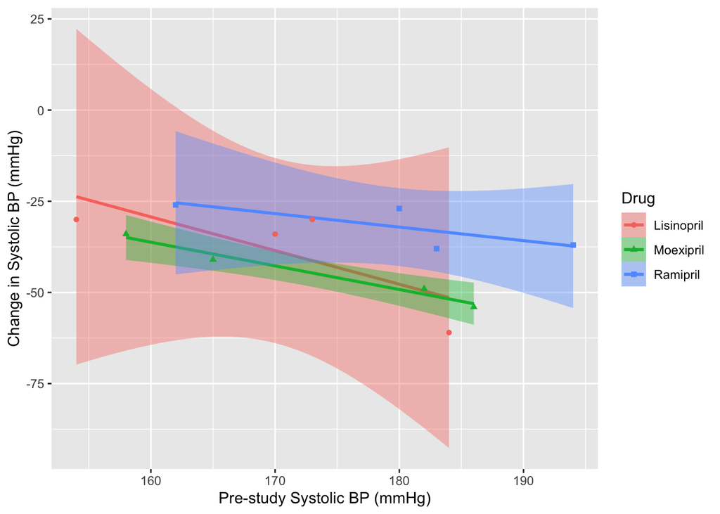

```r
# Visualization
ggplot(bpdata, aes(x=SysBP.pre, y=BPchange, shape=Drug, colour=Drug, fill=Drug)) +
  geom_smooth(method="lm") +
  geom_point() +
  labs(x = "Pre-study Systolic BP (mmHg)",
       y = "Change in Systolic BP (mmHg)")
```

```r
# Modeling
ancova2 <- aov(BPchange ~ SysBP.pre + Drug, data = bpdata)
summary(ancova2)
```

```
##             Df Sum Sq Mean Sq F value Pr(>F)
## SysBP.pre    1  360.3   360.3   7.046 0.0291 *
## Drug         2  569.5   284.7   5.568 0.0305 *
## Residuals    8  409.1    51.1
## ---
## Signif. codes:  0 '***' 0.001 '**' 0.01 '*' 0.05 '.' 0.1 ' ' 1
```

### Assessing the “randomization” claim

Of course we would look at the ‘pre’ scores to investigate. If randomization were done, the expectation would be that the distributions of pre-treatment BPs would be the same in all groups. Approaches to this may include:

1. One way ANOVA (paramteric, strong assumptions made, only compares distributional means)

```r
# ANOVA to assess equality of pre-study BP across groups
anova_random <- aov(SysBP.pre ~ Drug, data = bpdata)
summary(anova_random)
```

```
##             Df Sum Sq Mean Sq F value Pr(>F)
## Drug         2    194    97.0   0.571  0.584
## Residuals    9   1528   169.8
```

2. Kruskal-Wallis test (nonparametric one-waky ANOVA on ranks – assesses location differences only)

```r
# Nonparametric test to compare distributions of pre-study BP
kruskal.test(SysBP.pre ~ Drug, data = bpdata)
```

```
##
##  Kruskal-Wallis rank sum test
##
## data:  SysBP.pre by Drug
## Kruskal-Wallis chi-squared = 0.80769, df = 2, p-value = 0.6677
```